# HW2 Web Site - PCA Image Compression

Archita Roy

2026-09-19

# PCA Image Compression

This website explores image compression using Principal Component Analysis (PCA). For each image, I will compare the original image to rank-k PCA approximations and examine how the approximation error changes as k increases.

# Image Compression Function

The following image compression function takes an image matrix and a value of k. It returns the rank-k PCA approximation and its Frobenius norm error.

```r
compress_image = function(X, k) {

  X = data.matrix(X)
  pca = prcomp(X, center = FALSE, scale. = FALSE)

  if (k < 1 || k > ncol(pca$x)) {
    stop("k must be between 1 and ", ncol(pca$x))
  }

  scores_k = pca$x[, 1:k, drop = FALSE]
  loadings_k = pca$rotation[, 1:k, drop = FALSE]

  Xk = scores_k %*% t(loadings_k)

  error = norm(X - Xk, type = "F")

  return(list(
    approximation = Xk,
    error = error
  ))
}
```

# Image 1

## Original Image and PCA Approximations

The following plots show the original image followed by the rank-k PCA approximations for k = 1 through 10.

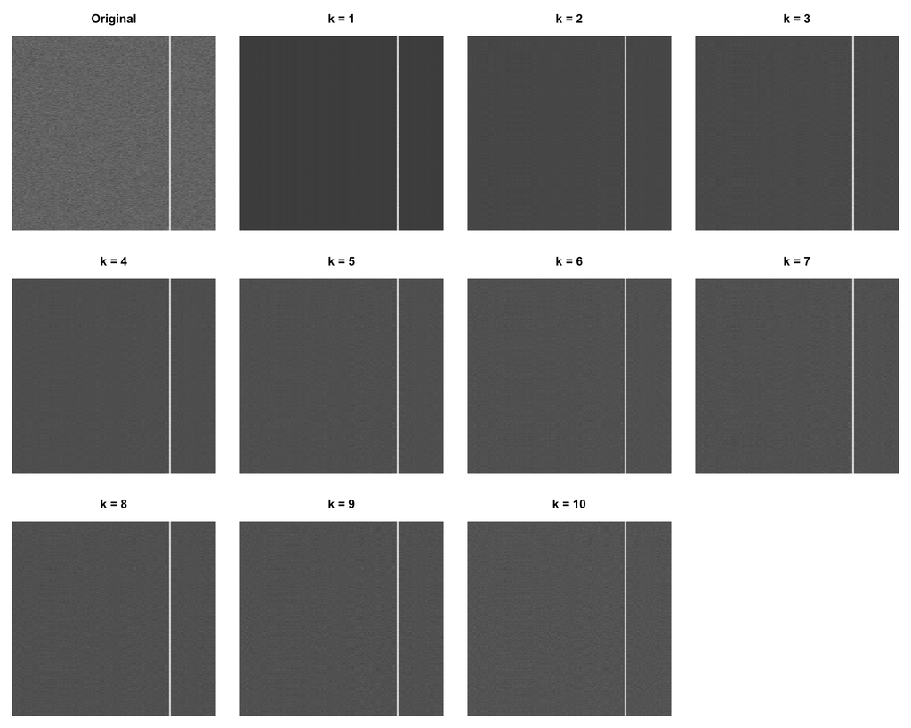

## Approximation Error

The following plot shows the Frobenius norm approximation error for all possible values of k.

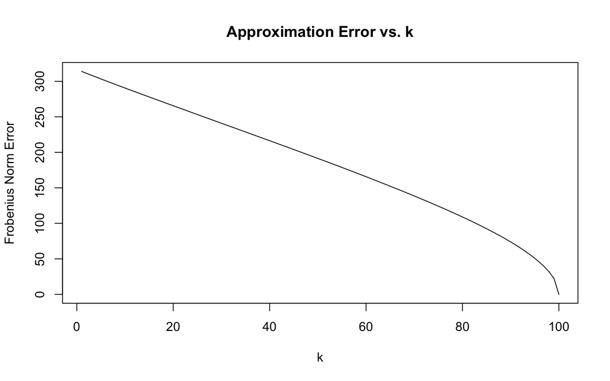

As k increases, the approximation error decreases because more principal components are being used to reconstruct the original image.

## First Eigenvector and First PC Score

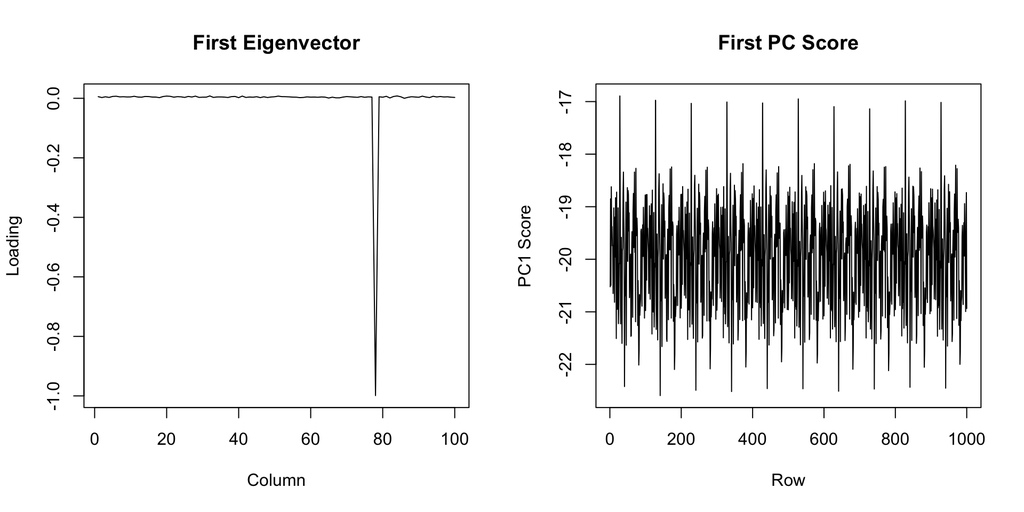

### Interpretation

Unlike a smooth or slowly-varying pattern, the first eigenvector for Image 1 is close to flat across most columns, with one sharp downward spike around column 75-80. That spike lines up with the thin vertical seam visible in the original image and in every k = 1…10 approximation above, so the dominant uncentered component is essentially detecting “how strong is the pixel value right at that seam,” rather than describing a broad gradient across the whole image. Consistent with that, the first PC score sits at a roughly constant level (around -17 to -22) across all 1000 rows instead of swinging widely, meaning nearly every row activates that seam feature to about the same degree. This localized, spike-like structure - rather than a smooth global pattern - is also why the error curve declines gradually and needs a large fraction of the available components before flattening out: a single sharp local feature does not compress nearly as efficiently as a smooth, broadly-shared one.

# Image 2

## Original Image and PCA Approximations

The following plots show the original image followed by the rank-k PCA approximations for k = 1 through 10.

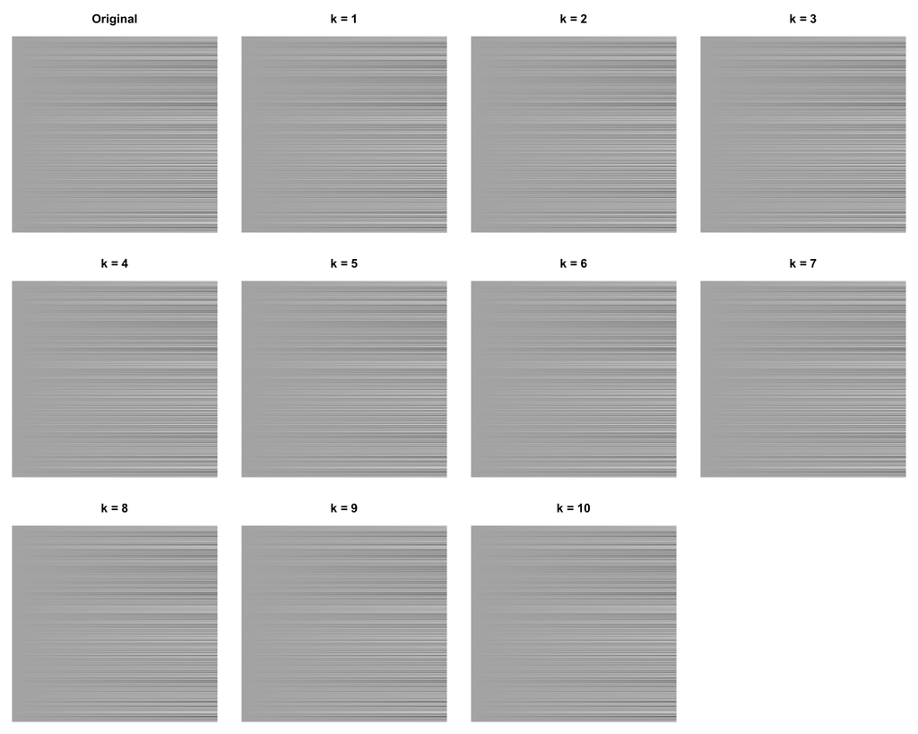

## Approximation Error

The following plot shows the Frobenius norm approximation error for all possible values of k.

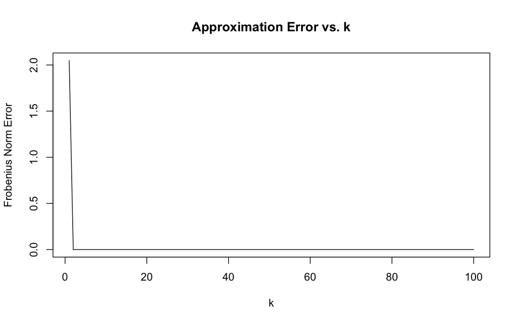

As k increases, the approximation error decreases because more principal components are being used to reconstruct the original image.

## First Eigenvector and First PC Score

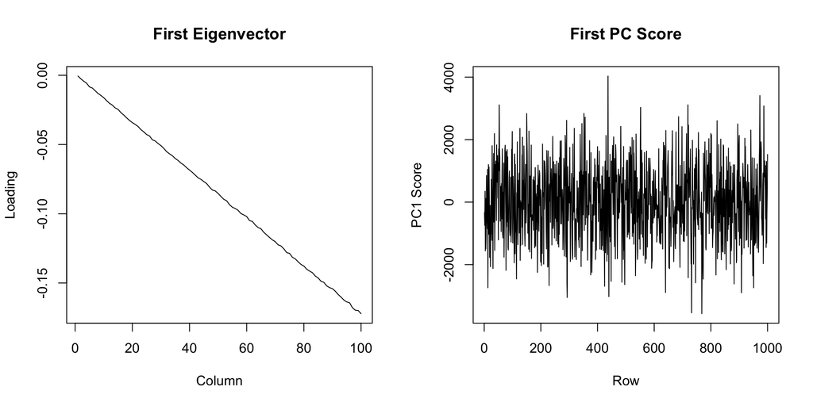

### Interpretation

Image 2’s first eigenvector is a smooth, almost perfectly straight line declining from 0 to about -0.17 across the 100 columns - a pure left-to-right brightness gradient, with no zigzag or local features. The first PC score, in contrast, swings widely from about -2000 to +4000 across the 1000 rows. Put together, this says the image is essentially one fixed spatial pattern (that linear gradient) whose intensity is simply scaled up or down row by row - some rows are a strongly negative multiple of the gradient, others a strongly positive multiple, but every row shares the same underlying shape. That is exactly the signature of a (nearly) rank-1 matrix, and it matches the error curve directly: error starts at about 2 at k = 1 and drops to essentially 0 by k = 2-3, orders of magnitude smaller than image 1’s errors at the same k.

### Sufficient Approximation

I think k = 2 provides a sufficiently good approximation of Image 2 because the error curve shows the reconstruction is already at essentially 0 (down from about 2 at k = 1) by k = 2-3 and stays flat all the way out to k = 100 - additional components contribute nothing, which is consistent with the image being very close to a rank-1 or rank-2 matrix by construction.

# Image 3

## Original Image and PCA Approximations

The following plots show the original image followed by the rank-k PCA approximations for k = 1 through 10.

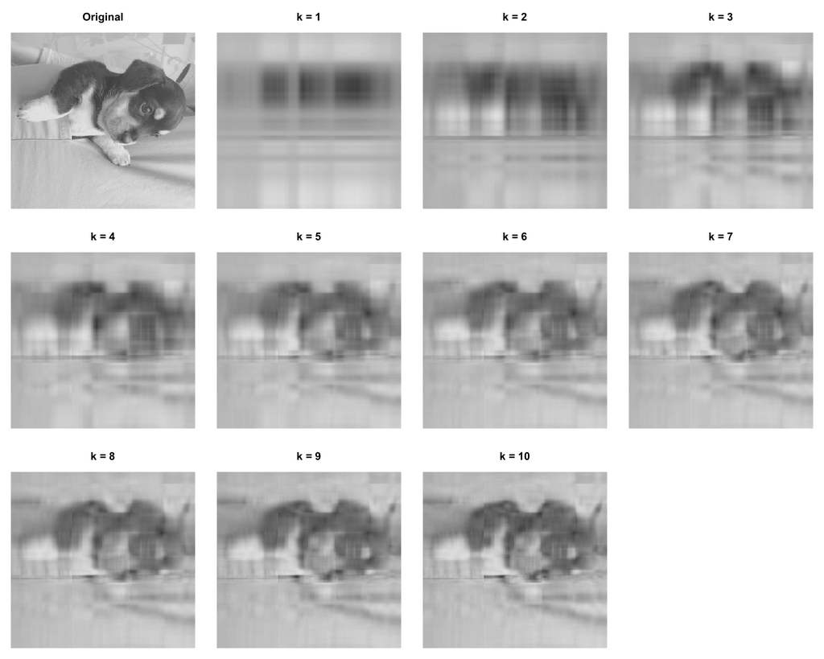

## Approximation Error

The following plot shows the Frobenius norm approximation error for all possible values of k.

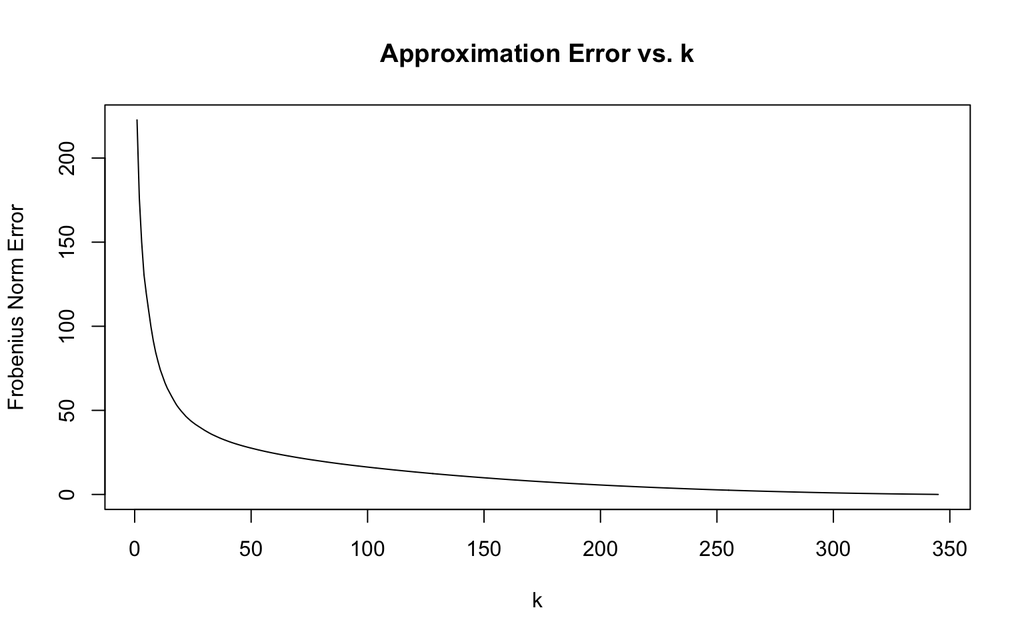

As k increases, the approximation error decreases because more principal components are being used to reconstruct the original image.

## First Eigenvector and First PC Score

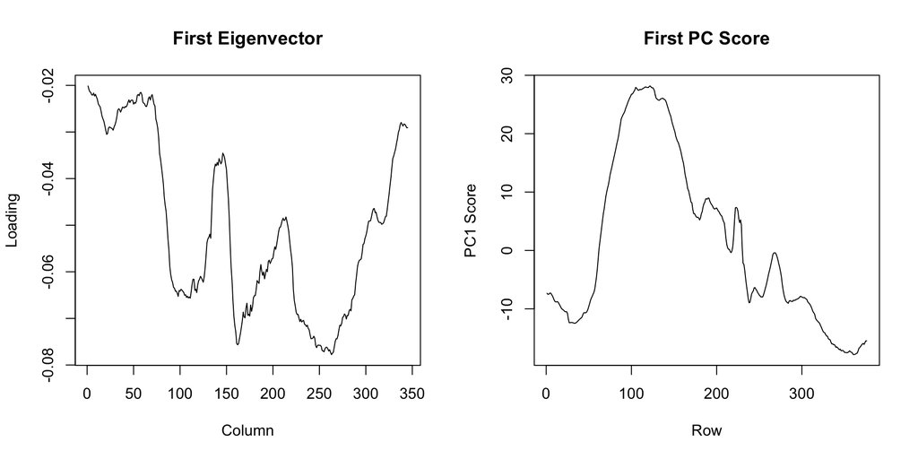

### Sufficient Approximation

I think k = 40 provides a sufficiently good approximation of Image 3 because the error curve falls steeply over the first few dozen values of k and then flattens noticeably, and by k = 10 the subject is already recognizable but still visibly soft in the k = 1…10 grid above - a k in the range where the curve has mostly leveled off gives a much sharper result without needing to approach the full rank (over 300) where the error finally reaches 0.

# Image 4

## Original Image and PCA Approximations

The following plots show the original image followed by the rank-k PCA approximations for k = 1 through 10.

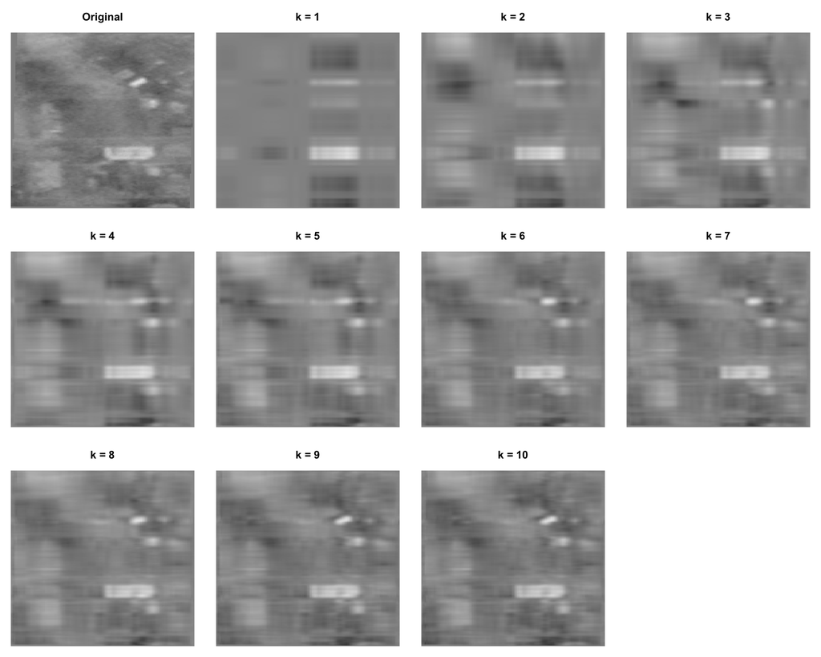

## Approximation Error

The following plot shows the Frobenius norm approximation error for all possible values of k.

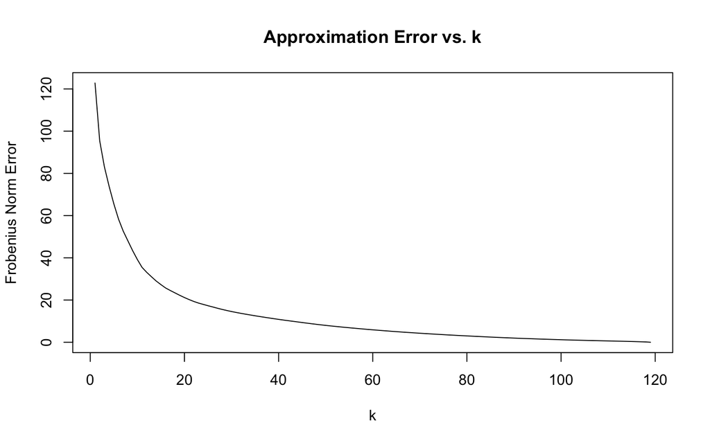

As k increases, the approximation error decreases because more principal components are being used to reconstruct the original image.

## First Eigenvector and First PC Score

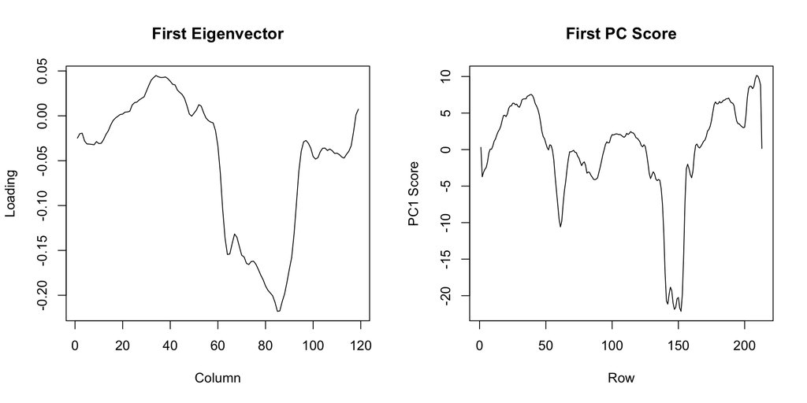

### Interpretation

Image 4’s first eigenvector rises to a modest peak (about 0.04) around columns 30-40, then drops sharply to a deep trough of about -0.22 near column 85, before recovering back toward 0 by column 120. The first PC score shows a matching sharp trough of about -22 around rows 145-150, set against otherwise mild fluctuation between about -10 and 8 elsewhere. Both of these point to the same thing: a single strong, localized feature - almost certainly the bright rectangular object visible in the lower-middle portion of the original image - is dominating the first component, since a broad or evenly distributed pattern would not produce such a sharp, isolated extreme in both the column loadings and the row scores at matching locations.

### Sufficient Approximation

I think k = 20 provides a sufficiently good approximation of Image 4 because the error curve drops from about 120 at k = 1 to a small fraction of that within the first 20 or so components and flattens well before reaching its full rank of about 120, so a moderate k captures the dominant bright-object feature and most of the surrounding texture without needing to reconstruct the image essentially exactly.